# Part II - (Effect of Trip Characteristics on an Individuals decision to Share Ride)

## by (Fatiat Temitope Hammed)

## Investigation Overview

> In this investigation, I wanted to look at the trip or individuals characteristics that could predict a riders decision to share bike during a trip. The main focus was on the trip characteritics such as the duration, th day and period of take off, the riders age and user type.

## Dataset Overview

```python
# import all packages and set plots to be embedded inline
import numpy as np
import pandas as pd
import matplotlib.pyplot as plt
import seaborn as sb

%matplotlib inline

# suppress warnings from final output
import warnings
warnings.simplefilter("ignore")
```

```python
# load in the dataset into a pandas dataframe
tripdata = pd.read_csv('201902-fordgobike-tripdata.csv')
```

```python
#we drop null values and columns not necessary
df = tripdata.dropna()
df = df.drop(['start_station_latitude', 'start_station_longitude', 'end_station_latitude',  'end_station_longitude'], axis=1)

# we derive column 'age' from birth year
df['age'] = 2019 - df['member_birth_year']

#we drop some rows with duration above 50000 seconds
df.drop(df[df['duration_sec'] >= 50000].index, inplace = True)

#we drop rows where the gender is not specified
df.drop(df[df['member_gender'] == 'Other'].index, inplace = True)
```

```python
# convert the timestamp column to datetime
df['start_time'] = pd.to_datetime(df['start_time'])

# extract hour from the timestamp column to create an time_hour column
df['start_hour'] = df['start_time'].dt.hour

#we split the day hour into various time of the day
df['start_period'] = (df['start_time'].dt.hour % 24 + 4) // 4
df['start_period'].replace({1: 'Late Night',
                      2: 'Early Morning',
                      3: 'Morning',
                      4: 'Noon',
                      5: 'Evening',
                      6: 'Night'}, inplace=True)


#we create column for the dayof the week
df['day'] = pd.to_datetime(df['start_time']).dt.day_name()
```

### Average Trip Duration

The trip duration has a long tail distribution. For easier visualization, we convert the duration from seconds to minutes and also plot on the log scale

[figure not shown]

```python
df['duration_min'] = df['duration_sec'] / 60

log_binsize = 0.1
bins = 10 ** np.arange(0, np.log10(df['duration_min'].max())+log_binsize, log_binsize)

plt.figure(figsize=[14, 8])
plt.hist(data = df, x = 'duration_min', bins = bins)
plt.xscale('log')
plt.xticks([1 , 3, 10, 30, 100, 300, 1e3, 3e3], ['1', '3', '10', '30', '1k', '3k'])
plt.xlabel('Trip Duration (minutes)')
plt.ylabel('Frequency')
plt.title('Average Trip Duration')
plt.show();
```

## Average age of bike riders

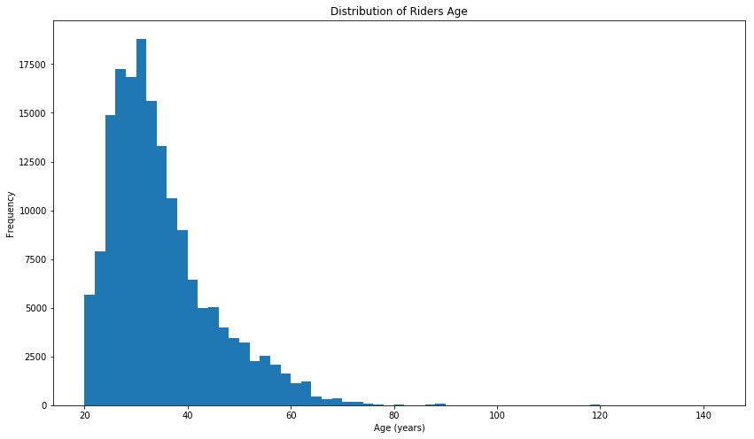

```python
binsize = 2
bins = np.arange(20, df['age'].max()+binsize, binsize)
plt.figure(figsize=[14, 8])
plt.hist(data = df, x = 'age', bins = bins)
plt.xlabel('Age (years)')
plt.ylabel('Frequency')
plt.title('Distribution of Riders Age')
plt.show();
```

### Gender, User type and Bike Share Distribution

Most of the riders are subsribers with few customers. There is high number of male riders compared to female. Also very low population share their bike rides.

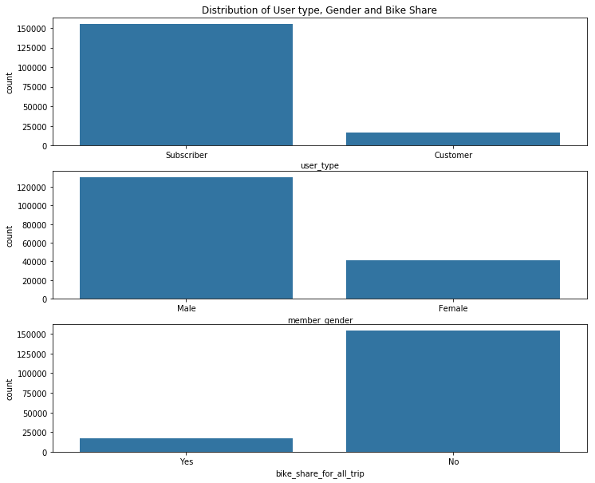

```python
fig, ax = plt.subplots(nrows=3, figsize = [12, 10])

default_color = sb.color_palette()[0]
sb.countplot(data = df, x = 'user_type', color = default_color, ax = ax[0])
sb.countplot(data = df, x = 'member_gender', color = default_color, ax = ax[1])
sb.countplot(data = df, x = 'bike_share_for_all_trip', color = default_color, ax = ax[2]);
ax[0].set_title('Distribution of User type, Gender and Bike Share');
```

### Days of the Week Distribution

Most bike rides start in the evening and morning as compared to other periods in the day. Most frequent days of rides are Thursdays and Tuesdays with weekends having the lowest frequency.

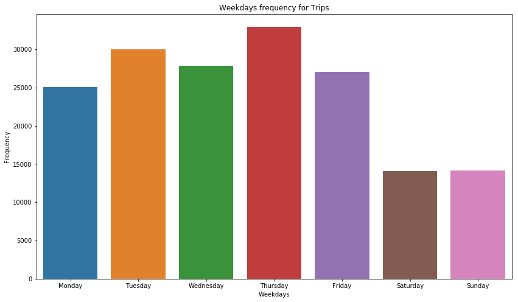

```python
plt.figure(figsize=[14, 8])
day_order = ["Monday", "Tuesday", "Wednesday", "Thursday", "Friday", "Saturday", "Sunday"]
sb.countplot(x = "day", data = df, order = day_order)
plt.xlabel('Weekdays')
plt.ylabel('Frequency')
plt.title('Weekdays frequency for Trips');
```

### Period of the day Frequency

Most bike rides start in the evening and morning as compared to other periods in the day.These peak periods are expected as they are work hours

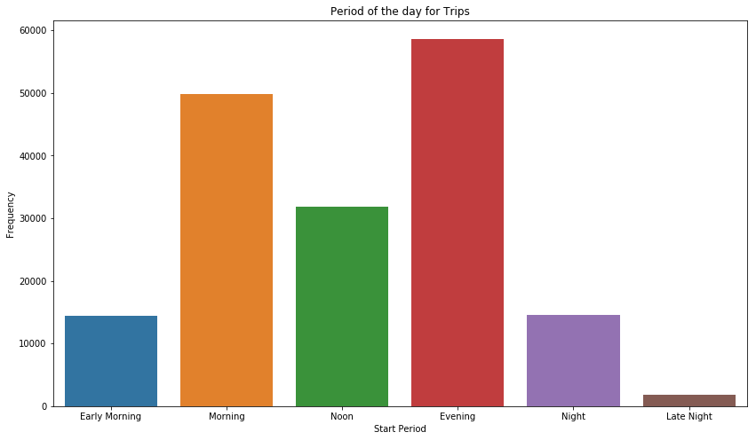

```python
plt.figure(figsize=[14, 8])
day_order = ["Early Morning", "Morning", "Noon", "Evening", "Night", "Late Night"]
sb.countplot(x = "start_period", data = df, order = day_order)
plt.xlabel('Start Period')
plt.ylabel('Frequency')
plt.title('Period of the day for Trips');
```

## Trip Duration Vs Age

Surprisingly,even using the log value for trip duration,we did not observe any strong correllation between the trips duration and individual age.

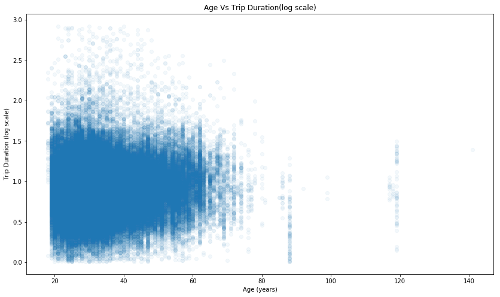

```python
numeric_vars = ['duration_min', 'age', ]
categoric_vars = ['member_gender', 'user_type', 'bike_share_for_all_trip', 'start_period', 'day']
# compute the logarithm of duration_min to make multivariate plotting easier
def log_trans(x, inverse = False):
    if not inverse:
        return np.log10(x)
    else:
        return np.power(10, x)
df['log_duration'] = df['duration_min'].apply(log_trans)
plt.figure(figsize = [14, 8])
plt.scatter(data = df, x = 'age', y = 'log_duration', alpha = 0.05)
plt.xlabel('Age (years)')
plt.ylabel('Trip Duration (log scale)')
plt.title('Age Vs Trip Duration(log scale)');
```

## Trip Duration and Age Vs User type, Gender and Day

[figure not shown]

```python
fig, ax = plt.subplots(ncols = 2, nrows = 5 , figsize = [14,8])
age_ticks = [0, 20, 40, 60, 80, 100]
for i in range(len(categoric_vars)):
    var = categoric_vars[i]
    sb.violinplot(data = df, x = var, y = 'log_duration', ax = ax[i,0],
               color = default_color)
    sb.violinplot(data = df, x = var, y = 'age', ax = ax[i,1],
               color = default_color)
    ax[i,1].set_yticklabels(age_ticks)
    fig.suptitle('Trip Duration and Age by Categorical Variable');
```

## Bike Share Vs Age

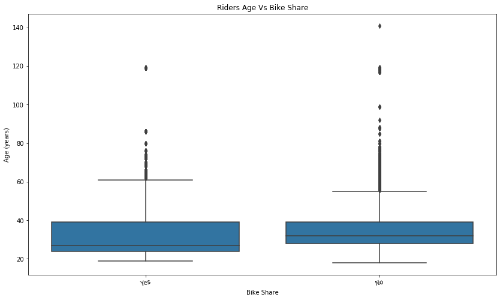

```python
plt.figure(figsize=[14, 8])
base_color = sb.color_palette()[0]
sb.boxplot(data = df, x = 'bike_share_for_all_trip', y = 'age',
              color = base_color)
plt.xticks(rotation = 15)
plt.xlabel('Bike Share')
plt.ylabel('Age (years)')
plt.title('Riders Age Vs Bike Share');
```

## Bike share Vs Other Bike ride Characteristics

From the categorical data, we observe that more subscribers share their bike ride than customers. Ride share frequency in the evening and afternoon tends to be higher than other time of the day. With regards to the day of the week, less ride trips are taken on weekends compared to weekdays and thereby also expected that less ride share will take placeon these days

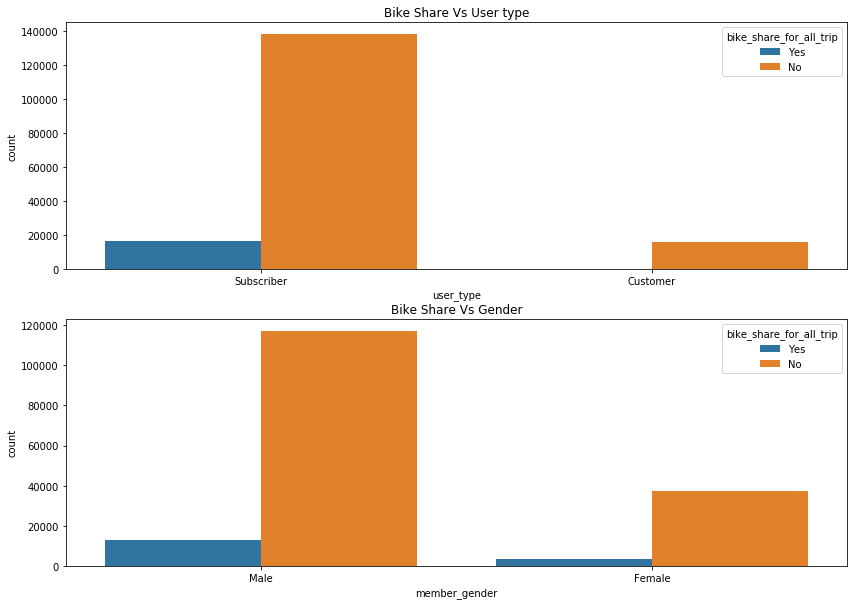

```python
fig, ax = plt.subplots(nrows=2, figsize = [14, 10])
default_color = sb.color_palette()[0]
sb.countplot(data = df, x = 'user_type', hue = 'bike_share_for_all_trip', ax = ax[0])
ax[0].set_title('Bike Share Vs User type')
sb.countplot(data = df, x = 'member_gender', hue = 'bike_share_for_all_trip', ax = ax[1])
ax[1].set_title('Bike Share Vs Gender');
```

## Bike share Vs Day

It is observed that even though weekends have the lowest frquency of trips, the frequency of individuals who share their ride during weekends are quiet noticeable.

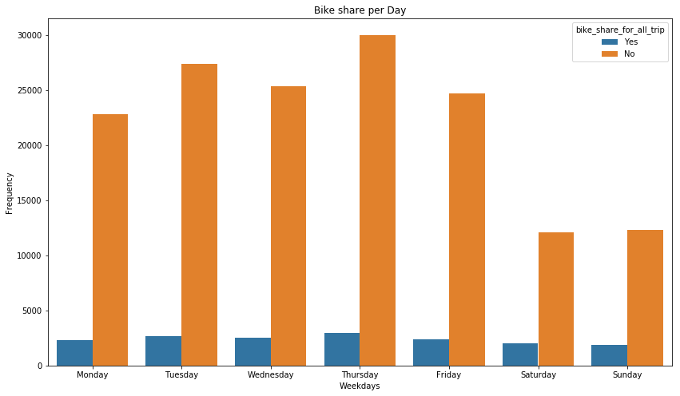

```python
plt.figure(figsize=[14, 8])
day_order = ["Monday", "Tuesday", "Wednesday", "Thursday", "Friday", "Saturday", "Sunday"]
sb.countplot(data = df, x = 'day', order= day_order, hue = 'bike_share_for_all_trip')
plt.xlabel('Weekdays')
plt.ylabel('Frequency')
plt.title('Bike share per Day');
```

## Bike share Vs Period of the Day

The most frequent period of ride is Evening and Morning. But compared to other periods it is observed that individuals who share bike most take off in the Evening and Noon compared to other periods of the day

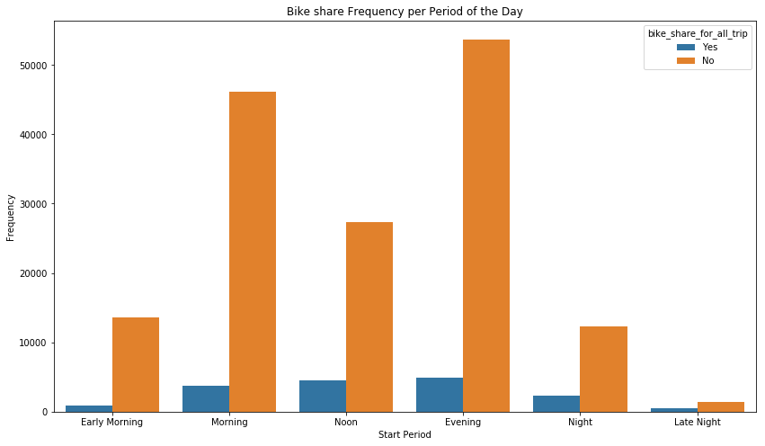

```python
plt.figure(figsize=[14, 8])
day_order = ["Early Morning", "Morning", "Noon", "Evening", "Night", "Late Night"]
sb.countplot(data = df, x = 'start_period', order = day_order, hue = 'bike_share_for_all_trip')
plt.xlabel('Start Period')
plt.ylabel('Frequency')
plt.title('Bike share Frequency per Period of the Day');
```

## Age by Bike Share and User type

Compared to customers, subscribers of younger age are major set of individuals that share their trip ride.

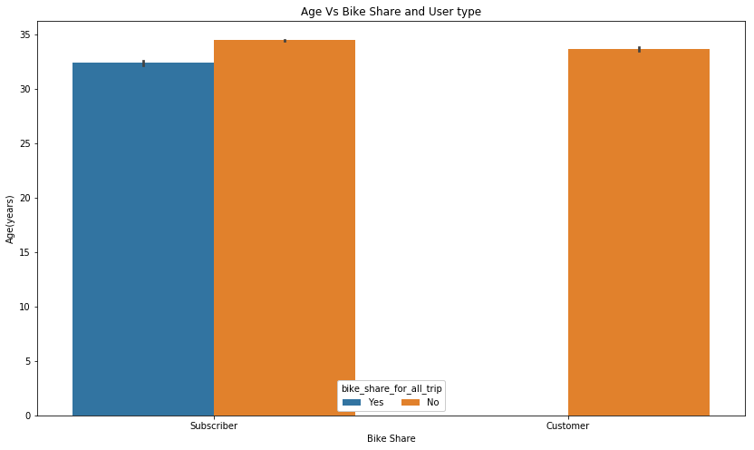

```python
plt.figure(figsize=[14, 8])
ax = sb.barplot(data = df, x = 'user_type', y = 'age', hue = 'bike_share_for_all_trip')
ax.legend(loc = 8, ncol = 3, framealpha = 1, title = 'bike_share_for_all_trip')
plt.xlabel('Bike Share')
plt.ylabel('Age(years)')
plt.title('Age Vs Bike Share and User type');
```

## Age by Bike share and Start Period

While the average age of riders is 35years, it is observed that the younger riders in all the periods of the day tends to share their bike trips more that older individuals.

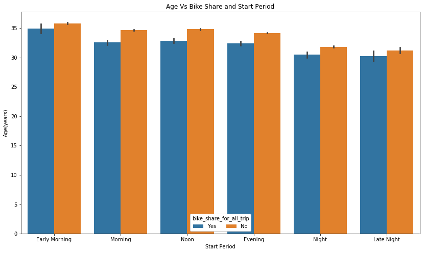

```python
plt.figure(figsize=[14, 8])
day_order = ["Early Morning", "Morning", "Noon", "Evening", "Night", "Late Night"]
ax = sb.barplot(data = df, x = 'start_period', order = day_order, y = 'age', hue = 'bike_share_for_all_trip')
ax.legend(loc = 8, ncol = 3, framealpha = 1, title = 'bike_share_for_all_trip')
plt.xlabel('Start Period')
plt.ylabel('Age(years)')
plt.title('Age Vs Bike Share and Start Period');
```

### Conclusions

From the investigation in finding out factors to predict an individuals decision to share ride, our findings are; Riders below the age of 35years tends to share their bike than riders older Subscribers share their bike more than customers Ride share are more frequent in the evening and noon than any other period of the day

```python
!jupyter nbconvert presentation.ipynb --to slides --no-input --no-prompt
```

```
[NbConvertApp] Converting notebook presentation.ipynb to slides
[NbConvertApp] Writing 795554 bytes to presentation.slides.html
```